# Predict Probability of Sales on Inbound Call Center Traffic

## Project description

This project aims at predicting the sale on next call based on caller’s demographic, socio economic data, location and the source of traffic (paid, SEO or affiliate). A sale comprises sale of any combination of cable, internet or phone service to a residential caller in any part of US depending on the availability of service at the caller’s address. Call center sales agents have access to order entry tool for almost all the major cable, internet and phone service providers in the country which enables them to sell any provider the caller is looking for.

Ordering cable, internet and phone services is a complex process that requires customization and selection of many features on callers part and also because the price a customer pays on a monthly basis, varies with the choice of channels selection for a cable product, speed of internet package and in case of phone whether in-state or out-of-state calling is selected or not. People usually need assistance in order to order services and hence call in.

Before calling, callers generally search online to get an idea of what they should order and who to reach out to in order to get services. The search is mostly carried out on some of the popular search engines such as google, bing, yahoo etc. This particular call center markets its services on these search engines to generate demand and to drive calls to the center.

```
## [1] "C/C/C/C/C/en_US.UTF-8"
```

A brief description of the variables in the data set is as follows:

1. Call.Date : Captures the day of month when the call arrived. The dataset has calls answered for all 31 days in May.
2. CallStartTime: Time when call started
3. CallEndTime: Time when call ended
4. Outcome: This captures whether a call got successfully connected to an agent or not. For this analysis, all connected calls have been taken. This variable does not have any preditive capability and will be dropped.
5. AgentID: Every agent in the center is assigned a unique ID captured by AgentID field.
6. TFN : The toll free name dialled by the customer to reach us to order services
7. BTN : Phone number of the customer
8. CallSkill : Agents are divided into various skill in the call center. A skill comprises a group of agents who are expert in selling a particular group of services. Some agents are multiskilled. CallSkill is the skill of the agent who answered the call.
9. OrigianlSkill: In case all agents on a skill are busy, the call is answered by the next available agent on another skill. The agent who was originally supposed to answer the call is captured by OriginalSkill variable.
10. CableCompany: THere are 24 skills in the center.
11. Affiliate: In addition to generating demand by marketing on search engines, some third party parnters also send traffic to the call center. They use a mix of marketing channels to drive traffic. The name of an affiliate is captured by this variable. The call center’s own sources of traffic are grouped under “Digital Globe Services” to differentiate from the rest.
12. Disposition: At the end of a call the call center agent classifies a call as sales/non-sales calls captured by the disposition variable. To better understand what happened on a call, disposition field helps capture the caller intent. A sale could be a sale of one service (A single play sale), two services (a double play sale), three services (a triple play sale), or four services (a quad play). The revenue generated on a call depends on the number of services sold.

## Data Cleaning

The disposition of the call depends on a number of factors such as the area the caller was calling from, the affiliate that drove the call, call skill and the TFN. A more detailed explanation of each varilable and cleaning the data is presented below. 1. TFN

There are 5,414 unique TFNs in the data set. The number of calls offered on each TFN ranges from 1 call answered to a maximum of 9,991 calls answered. The median number of calls answered is 6 while mean is 75.6 which suggests that some TFNs get a large number of calls while others obtain a few. Disecting this variable a little more shows that 77 out of the 5,414 TFNs have 1000 or more calls.

The AgentID field shows that there are 689 agents who answered the phones in May. Median number of calls answered was 690.

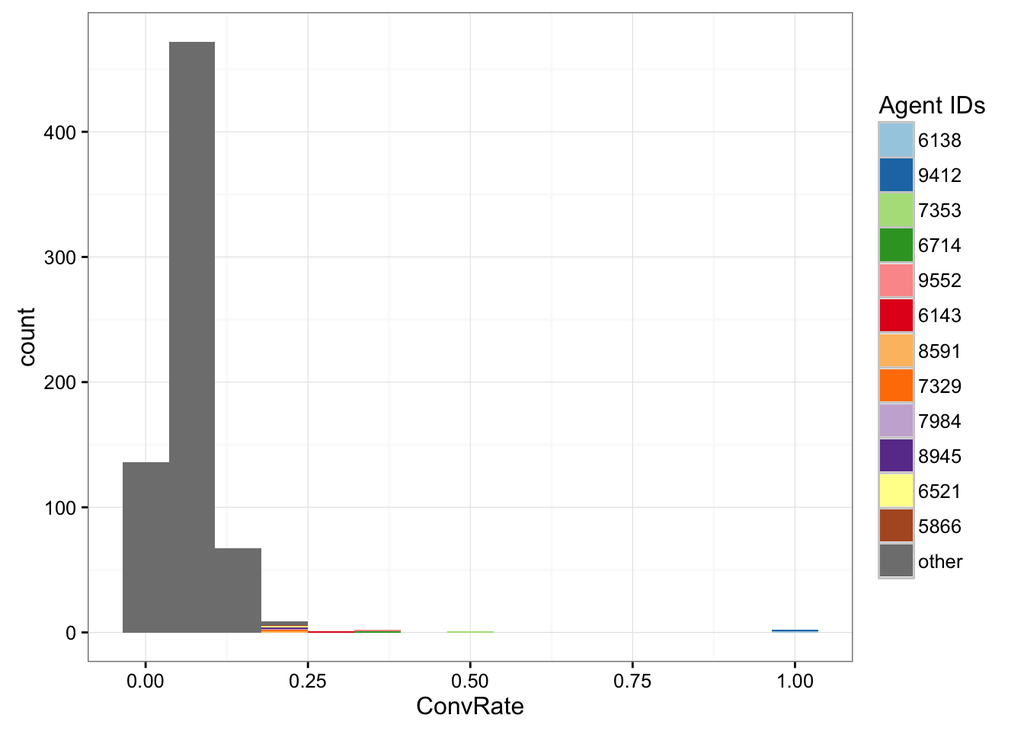

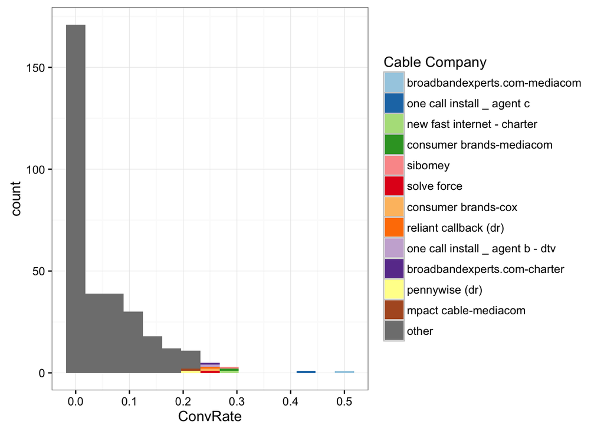

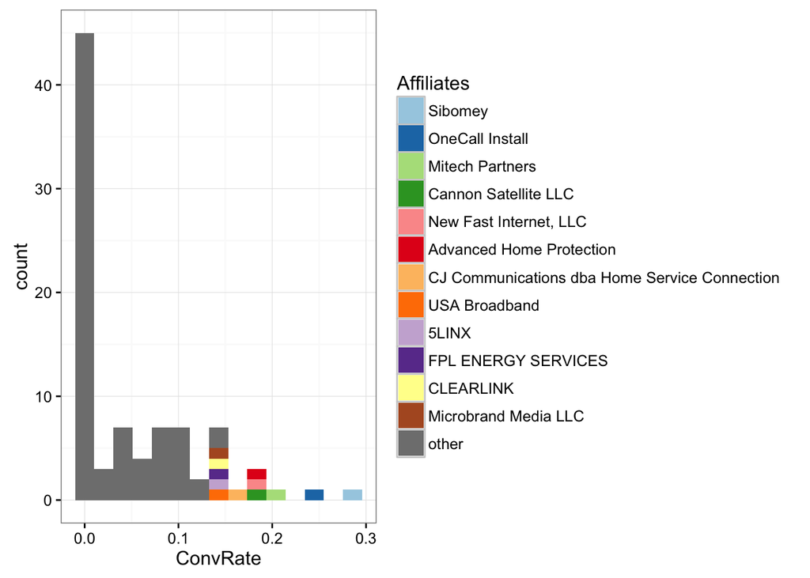

TFNs vs sales ratio plots

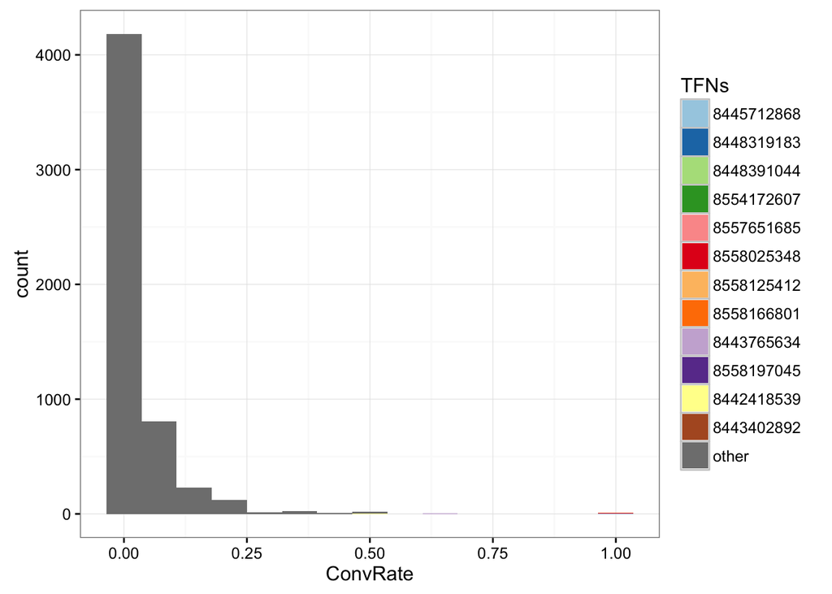

Call Skill vs sales ratio plot

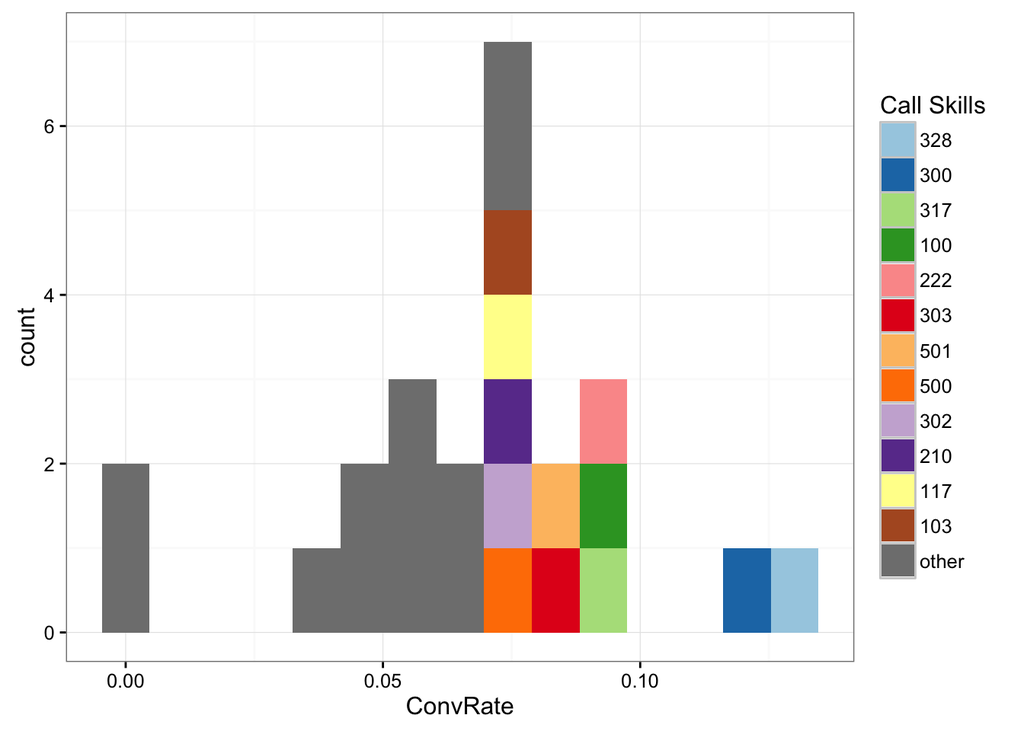

Original Skill vs sales ratio plot

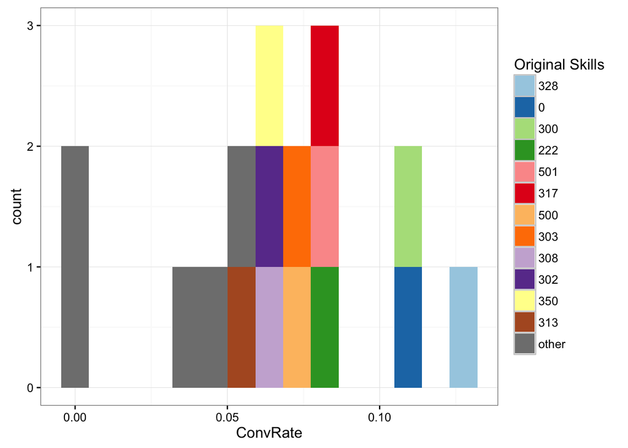

Area Code vs sales conversions plot

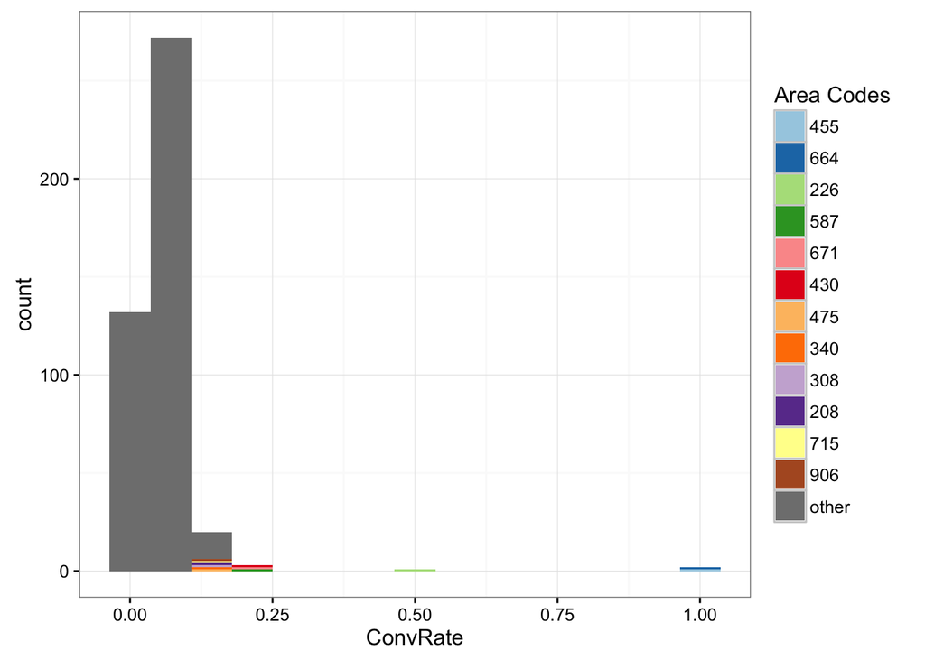

Disposition fields captures the end of call status whether it was a sale or otherwise. Since we are trying to predict whether a call will result in a sale or not and the associated probabilities, the disposition variable to reduced to a sale/no sale variable. 93% of all calls did not result in a sales while sales close rate is roughly 7%.

```
##
## No Sale    Sale
##    0.93    0.07
```

```
## Analysis of Variance Table
##
## Response: SaleCode
##            Df Sum Sq  Mean Sq F value  Pr(>F)
## Affiliate  31  2.593 0.083642  1.6339 0.01705 *
## AreaCode  249 15.236 0.061190  1.1953 0.03958 *
## Residuals 719 36.807 0.051192
## ---
## Signif. codes:  0 '***' 0.001 '**' 0.01 '*' 0.05 '.' 0.1 ' ' 1
```

```
## # A tibble: 330 x 2
##                                    CableCompany PercentOfTot
##                                           <chr>        <dbl>
## 1                                               2.596545e-03
## 2                                    10channels 2.482357e-06
## 3                          2turniton - outbound 7.322952e-04
## 4                                         5linx 3.847653e-04
## 5                                   732 numbers 2.482357e-06
## 6                    732 numbers charter retail 2.482357e-05
## 7                          732numbers earthlink 4.915066e-04
## 8  76766 -�nuhome promotions - mso - twc 9.681191e-05
## 9         80191 - nuhome promotions - mso - cox 1.092237e-04
## 10                                      abenity 9.929427e-06
## # ... with 320 more rows
```

```
## [1] "Percent of Affiliate, Pr(Affiliate)"
```

```
## # A tibble: 89 x 2
##                   Affiliate PercentOfTot
##                       <chr>        <dbl>
## 1                10Channels 2.482357e-06
## 2             2TurnItOn.com 7.322952e-04
## 3                     5LINX 3.847653e-04
## 4           732-Numbers LLC 1.380190e-03
## 5                   ABENITY 9.929427e-06
## 6            AP Media Group 2.482357e-06
## 7              Acceller_DSI 6.429304e-04
## 8               Adknowledge 6.454127e-05
## 9  Advanced Home Protection 1.439767e-03
## 10          All Bundles LLC 2.482357e-06
## # ... with 79 more rows
```

```
## [1] "Percent of AreaCode, Pr(AreaCode)"
```

```
## # A tibble: 430 x 2
##    AreaCode PercentOfTot
##       <chr>        <dbl>
## 1       2.3 1.737650e-05
## 2       2.5 2.482357e-06
## 3       201 3.050816e-03
## 4       202 6.133903e-03
## 5       203 5.637432e-03
## 6       204 3.971771e-05
## 7       205 4.475689e-03
## 8       206 3.048334e-03
## 9       207 3.487711e-03
## 10      208 2.286250e-03
## # ... with 420 more rows
```

```
## [1] "Percent of Sale , Pr(C)"
```

```
## # A tibble: 2 x 2
##      Sale PercentOfTot
##     <chr>        <dbl>
## 1 No Sale   0.93362675
## 2    Sale   0.06637325
```

Probability of each factor level given conversation rate C

```
## [1] "Pr (Affiliate | C)"
```

```
## # A tibble: 45 x 2
##                                        Affiliate         Prob
##                                            <chr>        <dbl>
## 1                                  2TurnItOn.com 3.365996e-04
## 2                                          5LINX 8.601990e-04
## 3                                732-Numbers LLC 4.113995e-04
## 4                       Advanced Home Protection 3.777395e-03
## 5                          Broadband Corporation 3.739996e-05
## 6  CJ Communications dba Home Service Connection 4.226195e-03
## 7                                      CLEARLINK 1.563318e-01
## 8                                 CM Enterprises 5.609993e-04
## 9                           Cannon Satellite LLC 6.881592e-03
## 10                             Connect Your Home 1.126487e-01
## # ... with 35 more rows
```

```
## [1] "Pr (AreaCode | C)"
```

```
## # A tibble: 308 x 2
##    AreaCode         Prob
##       <chr>        <dbl>
## 1       201 0.0026179969
## 2       202 0.0056099933
## 3       203 0.0047497943
## 4       205 0.0052359937
## 5       206 0.0024309971
## 6       207 0.0038521954
## 7       208 0.0046375944
## 8       209 0.0035155958
## 9       210 0.0054603934
## 10      212 0.0005609993
## # ... with 298 more rows
```